# Assignment 6

Your Name here

2022-07-24

`Deleted header to document`

```r
#install.packages('readr')

library(readr)
library(dplyr)
library(car)
library(gvlma)
```

We are going to look at the property prices for Orange County. From there we are going to try and predict the sales price by linear regression.

# 1 Importing Data

Bring in the data and make sure the data types are correct. If not, make the proper changes. The file is located within this project. *data/prop_prices_reduced.csv*

```r
# No file exists in this location. Added dataset to location

Property <- read.csv("prop_prices_reduced.csv")

#Renaming column sale_def with an intuitive name: price

# library(dplyr) once it is referenced above, you dont need it here
Property <- rename(Property, price = sale_def)
```

# 2 Plotting

Plot histograms for all variables. Additionally, add scatterplots for the relationships between all quantitative variables.

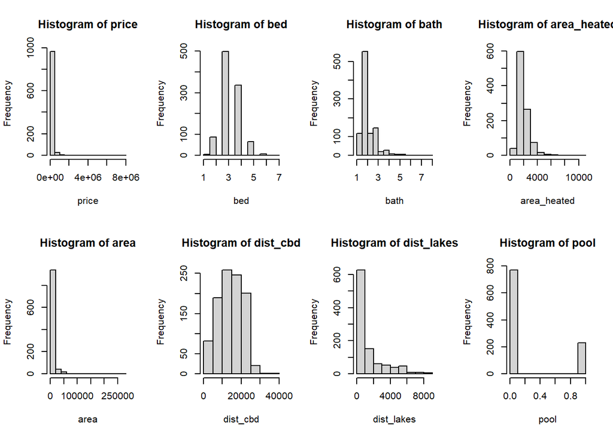

```r
# Histograms for all variables

attach(Property)
par(mfrow = c(2, 4))
hist(price)
hist(bed)
hist(bath)
hist(area_heated)
hist(area)
hist(dist_cbd)
hist(dist_lakes)
hist(pool)
```

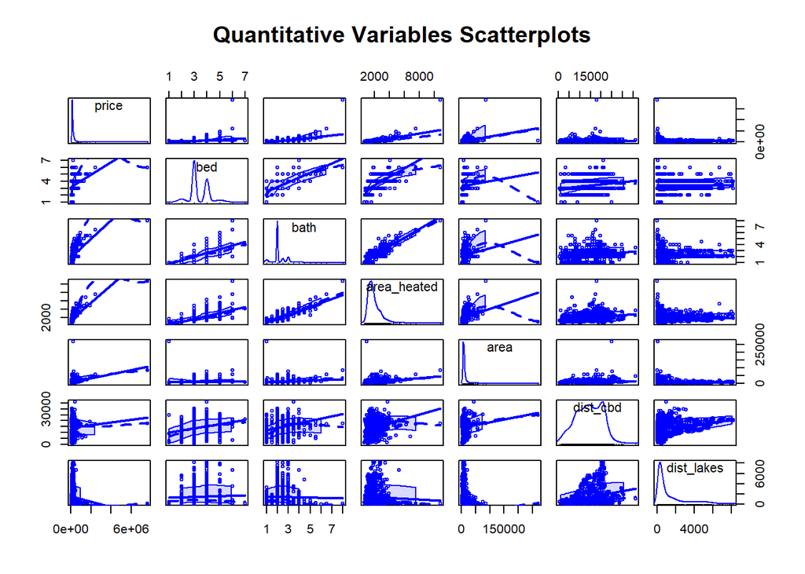

```r
# Scatterplots for the relationships between all quantitative variables
#library(dplyr)
PropertyQuant <- select(Property, price, bed, bath, area_heated, area, dist_cbd, dist_lakes)

#library(car)
scatterplotMatrix(PropertyQuant, main = "Quantitative Variables Scatterplots")
```

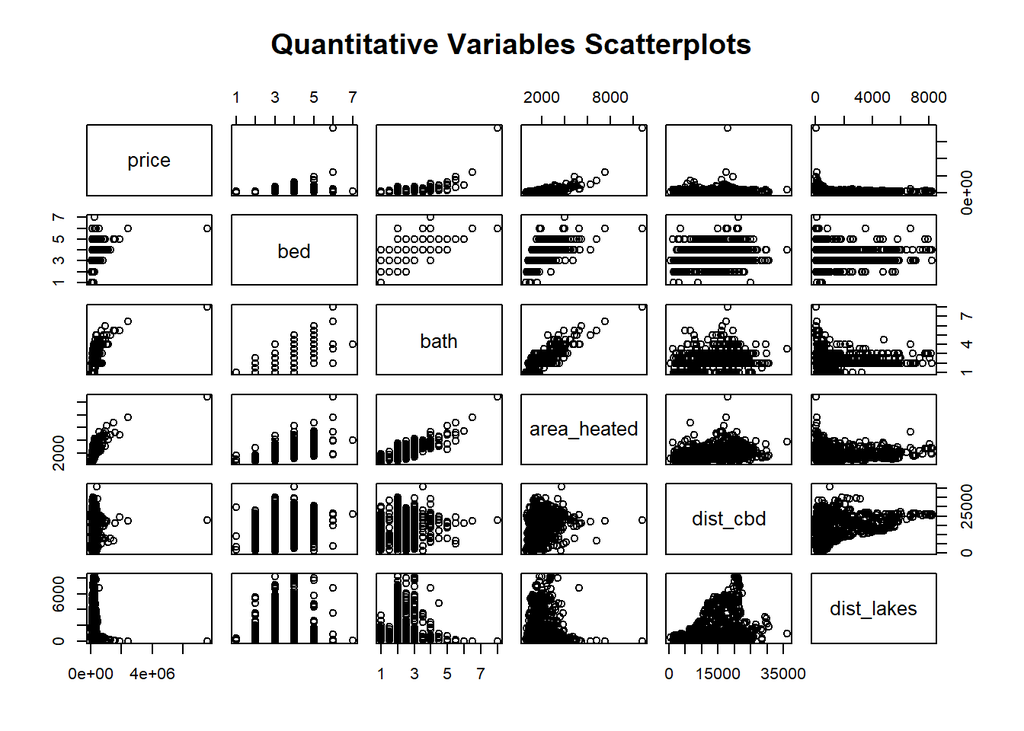

```r
# or
pairs(~price + bed + bath + area_heated + dist_cbd + dist_lakes, data = Property, main = "Quantitative Variables Scatterplots")
```

# 3 Summary Statistics

Provide basic summary statistics for univariate analysis. Also, provide the correlation between all the quantitative variables.

```r
# Factor in  data: Pool

Property$pool <- factor(Property$pool)

# Basis summary statistics
summary(Property)
```

```
##      price              bed             bath        area_heated
##  Min.   :  15296   Min.   :1.000   Min.   :1.000   Min.   :  650
##  1st Qu.: 115565   1st Qu.:3.000   1st Qu.:2.000   1st Qu.: 1387
##  Median : 151085   Median :3.000   Median :2.000   Median : 1744
##  Mean   : 200319   Mean   :3.398   Mean   :2.248   Mean   : 1955
##  3rd Qu.: 213902   3rd Qu.:4.000   3rd Qu.:2.500   3rd Qu.: 2301
##  Max.   :7629992   Max.   :7.000   Max.   :8.000   Max.   :10796
##       area           dist_cbd         dist_lakes      pool
##  Min.   :  1307   Min.   :  598.2   Min.   :  16.74   0:771
##  1st Qu.:  6498   1st Qu.: 9701.7   1st Qu.: 314.86   1:229
##  Median :  8733   Median :14552.0   Median : 638.82
##  Mean   : 10565   Mean   :14382.9   Mean   :1403.54
##  3rd Qu.: 11250   3rd Qu.:19369.2   3rd Qu.:1735.35
##  Max.   :269496   Max.   :36107.6   Max.   :8206.79
```

```r
# Correlation between all the quantitative variables
cor(PropertyQuant)
```

```
##                   price        bed        bath area_heated        area
## price        1.00000000 0.32557109  0.58731596  0.69201080  0.34354392
## bed          0.32557109 1.00000000  0.64449531  0.66911599  0.10437035
## bath         0.58731596 0.64449531  1.00000000  0.83255359  0.19298319
## area_heated  0.69201080 0.66911599  0.83255359  1.00000000  0.30184325
## area         0.34354392 0.10437035  0.19298319  0.30184325  1.00000000
## dist_cbd     0.05263700 0.23328277  0.24220637  0.25494517  0.08648327
## dist_lakes  -0.08857844 0.03747888 -0.02109154 -0.04092947 -0.15432291
##               dist_cbd  dist_lakes
## price       0.05263700 -0.08857844
## bed         0.23328277  0.03747888
## bath        0.24220637 -0.02109154
## area_heated 0.25494517 -0.04092947
## area        0.08648327 -0.15432291
## dist_cbd    1.00000000  0.26520451
## dist_lakes  0.26520451  1.00000000
```

# 4 Regression Analysis

Run a regression with all the variables included. Print results of the regression.

```r
Fit_property <- lm(price ~ bed + bath + area_heated + area + dist_cbd + dist_lakes + pool, data = Property)

summary(Fit_property)
```

```
##
## Call:
## lm(formula = price ~ bed + bath + area_heated + area + dist_cbd +
##     dist_lakes + pool, data = Property)
##
## Residuals:
##     Min      1Q  Median      3Q     Max
## -765238  -55999    9774   63848 4954827
##
## Coefficients:
##               Estimate Std. Error t value Pr(>|t|)
## (Intercept) -5.890e+04  3.093e+04  -1.904 0.057170 .
## bed         -8.492e+04  1.087e+04  -7.810 1.45e-14 ***
## bath         5.449e+04  1.507e+04   3.616 0.000315 ***
## area_heated  2.439e+02  1.430e+01  17.054  < 2e-16 ***
## area         3.548e+00  5.958e-01   5.955 3.61e-09 ***
## dist_cbd    -5.848e+00  1.090e+00  -5.366 1.00e-07 ***
## dist_lakes   9.651e-01  3.810e+00   0.253 0.800091
## pool1       -2.776e+04  1.640e+04  -1.693 0.090787 .
## ---
## Signif. codes:  0 '***' 0.001 '**' 0.01 '*' 0.05 '.' 0.1 ' ' 1
##
## Residual standard error: 194900 on 992 degrees of freedom
## Multiple R-squared:  0.547,  Adjusted R-squared:  0.5438
## F-statistic: 171.2 on 7 and 992 DF,  p-value: < 2.2e-16
```

Which of the variables tested significant at the 95% level? Looking at the results and answering outside of the chunk is sufficient.

The variables tested significant at the 95% level are bed, bath, area_heated, area and dist_cbd

## 4.1 Evaluating the model

As is, are any of the Gauss-Markov assumptions violated? If so, which ones? How can you fix the issues?

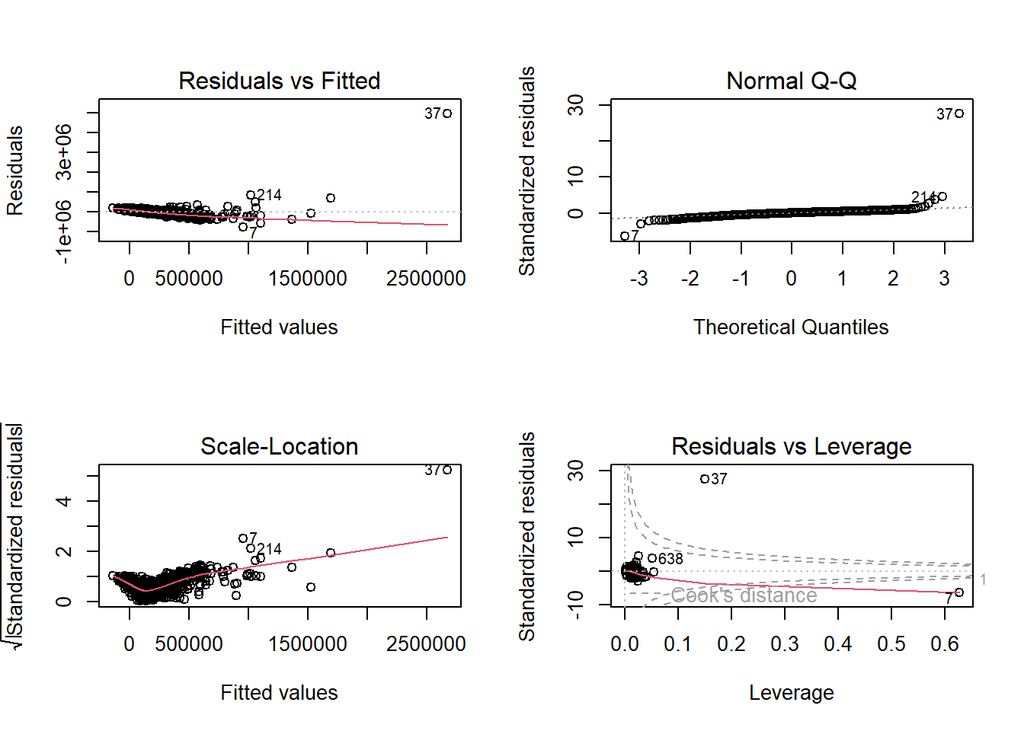

```r
#library(gvlma)
Fit_property <- lm(price ~ bed + bath + area + area_heated + dist_cbd + dist_lakes + pool, data = Property)


par(mfrow = c(2, 2))
plot(Fit_property)
```

```r
# Test of linear model assumptions
gvmodelProperty <- gvlma(Fit_property)
summary(gvmodelProperty)
```

```
##
## Call:
## lm(formula = price ~ bed + bath + area + area_heated + dist_cbd +
##     dist_lakes + pool, data = Property)
##
## Residuals:
##     Min      1Q  Median      3Q     Max
## -765238  -55999    9774   63848 4954827
##
## Coefficients:
##               Estimate Std. Error t value Pr(>|t|)
## (Intercept) -5.890e+04  3.093e+04  -1.904 0.057170 .
## bed         -8.492e+04  1.087e+04  -7.810 1.45e-14 ***
## bath         5.449e+04  1.507e+04   3.616 0.000315 ***
## area         3.548e+00  5.958e-01   5.955 3.61e-09 ***
## area_heated  2.439e+02  1.430e+01  17.054  < 2e-16 ***
## dist_cbd    -5.848e+00  1.090e+00  -5.366 1.00e-07 ***
## dist_lakes   9.651e-01  3.810e+00   0.253 0.800091
## pool1       -2.776e+04  1.640e+04  -1.693 0.090787 .
## ---
## Signif. codes:  0 '***' 0.001 '**' 0.01 '*' 0.05 '.' 0.1 ' ' 1
##
## Residual standard error: 194900 on 992 degrees of freedom
## Multiple R-squared:  0.547,  Adjusted R-squared:  0.5438
## F-statistic: 171.2 on 7 and 992 DF,  p-value: < 2.2e-16
##
##
## ASSESSMENT OF THE LINEAR MODEL ASSUMPTIONS
## USING THE GLOBAL TEST ON 4 DEGREES-OF-FREEDOM:
## Level of Significance =  0.05
##
## Call:
##  gvlma(x = Fit_property)
##
##                        Value p-value                   Decision
## Global Stat        7497980.4       0 Assumptions NOT satisfied!
## Skewness             45659.6       0 Assumptions NOT satisfied!
## Kurtosis           7450926.5       0 Assumptions NOT satisfied!
## Link Function          782.2       0 Assumptions NOT satisfied!
## Heteroscedasticity     612.1       0 Assumptions NOT satisfied!
```

All the Gauss-Markov assumptions (Global Stat, Skewness, Kurtosis, Link Function, Heteroscedasticity) are violated. To fix the issues, we will use the Box-Cox transformation or log() transformation to the dependent variable(price) and some of the independent variables to remove Heteroscedasticity. We will also remove some outlier to improve Skewness and Kurtosis. By doing all these manipulations, we hope that all the assumptions will be corrected.

`What about Assumption 1, 2, and 5?`

## 4.2 New Model

Based off of your findings in the previous section, make changes to the variables, the functional form, etc.

```r
summary(powerTransform(Property$price))
```

```
## bcPower Transformation to Normality
##                Est Power Rounded Pwr Wald Lwr Bnd Wald Upr Bnd
## Property$price   -0.3281       -0.33      -0.3966      -0.2597
##
## Likelihood ratio test that transformation parameter is equal to 0
##  (log transformation)
##                            LRT df       pval
## LR test, lambda = (0) 93.13327  1 < 2.22e-16
##
## Likelihood ratio test that no transformation is needed
##                            LRT df       pval
## LR test, lambda = (1) 2429.018  1 < 2.22e-16
```

```r
# The transformation parameter is -0.33 which is close to 0. We will do a log transformation of the price
```

```r
# log transformation of price
#library(car)
Property$logprice =log(Property$price)


#Verifying assumptions

#library(gvlma)

Fit_property1 <- lm(logprice ~ bed + bath + area + area_heated + dist_cbd + dist_lakes + pool, data = Property)

gvmodelProperty1 <- gvlma(Fit_property1)
summary(gvmodelProperty1)
```

```
##
## Call:
## lm(formula = logprice ~ bed + bath + area + area_heated + dist_cbd +
##     dist_lakes + pool, data = Property)
##
## Residuals:
##      Min       1Q   Median       3Q      Max
## -1.73772 -0.16388  0.00486  0.16609  1.09057
##
## Coefficients:
##               Estimate Std. Error t value Pr(>|t|)
## (Intercept)  1.102e+01  4.482e-02 245.905  < 2e-16 ***
## bed         -3.714e-02  1.576e-02  -2.357  0.01863 *
## bath         1.268e-01  2.184e-02   5.805 8.65e-09 ***
## area         2.599e-06  8.634e-07   3.010  0.00268 **
## area_heated  4.388e-04  2.073e-05  21.172  < 2e-16 ***
## dist_cbd    -6.945e-06  1.579e-06  -4.397 1.22e-05 ***
## dist_lakes  -1.476e-06  5.522e-06  -0.267  0.78926
## pool1        1.420e-01  2.376e-02   5.975 3.20e-09 ***
## ---
## Signif. codes:  0 '***' 0.001 '**' 0.01 '*' 0.05 '.' 0.1 ' ' 1
##
## Residual standard error: 0.2824 on 992 degrees of freedom
## Multiple R-squared:  0.7409, Adjusted R-squared:  0.7391
## F-statistic: 405.3 on 7 and 992 DF,  p-value: < 2.2e-16
##
##
## ASSESSMENT OF THE LINEAR MODEL ASSUMPTIONS
## USING THE GLOBAL TEST ON 4 DEGREES-OF-FREEDOM:
## Level of Significance =  0.05
##
## Call:
##  gvlma(x = Fit_property1)
##
##                      Value   p-value                   Decision
## Global Stat        341.505 0.000e+00 Assumptions NOT satisfied!
## Skewness            12.541 3.981e-04 Assumptions NOT satisfied!
## Kurtosis           281.102 0.000e+00 Assumptions NOT satisfied!
## Link Function       44.257 2.879e-11 Assumptions NOT satisfied!
## Heteroscedasticity   3.605 5.761e-02    Assumptions acceptable.
```

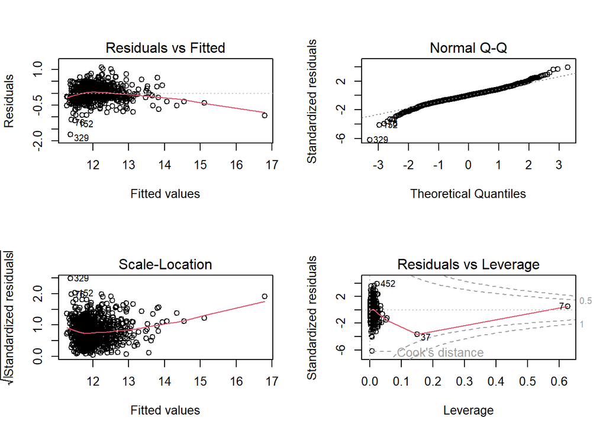

```r
par(mfrow = c(2, 2))
plot(Fit_property1)
```

```r
# Heteroscedasticity is now acceptable
```

Let’s do the log transformation of some other variables with skewed distributions to improve them

```r
Property$logarea= log(Property$area)
Property$logbath= log(Property$bath)
Property$logarea_heated = log(Property$area_heated)
Property$logDist_lakes = log(Property$dist_lakes)

# after several trials, I decided to not include the log of area

library(gvlma)
Fit_property2 <- lm(logprice ~ bed + logbath + area + logarea_heated + dist_cbd + logDist_lakes + pool, data = Property)

gvmodelProperty2 <- gvlma(Fit_property2)
summary(gvmodelProperty2)
```

```
##
## Call:
## lm(formula = logprice ~ bed + logbath + area + logarea_heated +
##     dist_cbd + logDist_lakes + pool, data = Property)
##
## Residuals:
##      Min       1Q   Median       3Q      Max
## -1.46479 -0.16527 -0.00692  0.17213  1.27569
##
## Coefficients:
##                  Estimate Std. Error t value Pr(>|t|)
## (Intercept)     4.134e+00  2.953e-01  14.000  < 2e-16 ***
## bed            -9.187e-02  1.643e-02  -5.591 2.91e-08 ***
## logbath         2.789e-01  4.418e-02   6.313 4.13e-10 ***
## area            4.592e-06  8.404e-07   5.464 5.88e-08 ***
## logarea_heated  1.094e+00  4.408e-02  24.815  < 2e-16 ***
## dist_cbd       -9.360e-06  1.591e-06  -5.884 5.49e-09 ***
## logDist_lakes  -2.808e-02  7.782e-03  -3.609 0.000323 ***
## pool1           1.353e-01  2.332e-02   5.803 8.75e-09 ***
## ---
## Signif. codes:  0 '***' 0.001 '**' 0.01 '*' 0.05 '.' 0.1 ' ' 1
##
## Residual standard error: 0.2769 on 992 degrees of freedom
## Multiple R-squared:  0.751,  Adjusted R-squared:  0.7493
## F-statistic: 427.5 on 7 and 992 DF,  p-value: < 2.2e-16
##
##
## ASSESSMENT OF THE LINEAR MODEL ASSUMPTIONS
## USING THE GLOBAL TEST ON 4 DEGREES-OF-FREEDOM:
## Level of Significance =  0.05
##
## Call:
##  gvlma(x = Fit_property2)
##
##                       Value   p-value                   Decision
## Global Stat        227.6826 0.000e+00 Assumptions NOT satisfied!
## Skewness             0.5796 4.465e-01    Assumptions acceptable.
## Kurtosis           161.0155 0.000e+00 Assumptions NOT satisfied!
## Link Function       65.1133 6.661e-16 Assumptions NOT satisfied!
## Heteroscedasticity   0.9741 3.237e-01    Assumptions acceptable.
```

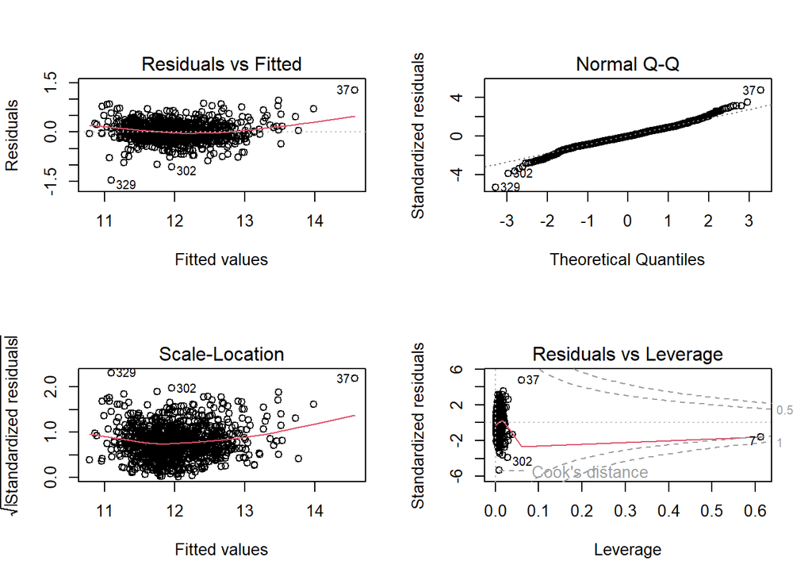

```r
par(mfrow = c(2, 2))
plot(Fit_property2)
```